# Another Variable Importance Measure to Consider

Aurora Owens

November 22nd, 2016

**Notes/ To Do**

- Decide if/if not to wrap the distribution procedure inside of a function
- Automatically compute another type of VIM for cases where the variable is not correlated with other predictors
- Move toward a bagged forest

In the previous documents the variable importance measure was defined as difference in the mean squared error of the tree before permutating the variable in question and after. Here, we’ll look at a variable importance measure that uses the built in deviance data in a `tree` object.

```r
library(MASS)
library(ggplot2)
library(dplyr)
library(tree)
library(grid)
library(gridExtra)
```

```r
# Multiple plot function
#
# ggplot objects can be passed in ..., or to plotlist (as a list of ggplot objects)
# - cols:   Number of columns in layout
# - layout: A matrix specifying the layout. If present, 'cols' is ignored.
#
# If the layout is something like matrix(c(1,2,3,3), nrow=2, byrow=TRUE),
# then plot 1 will go in the upper left, 2 will go in the upper right, and
# 3 will go all the way across the bottom.
#
multiplot <- function(..., plotlist=NULL, file, cols=1, layout=NULL) {
  library(grid)

  # Make a list from the ... arguments and plotlist
  plots <- c(list(...), plotlist)

  numPlots = length(plots)

  # If layout is NULL, then use 'cols' to determine layout
  if (is.null(layout)) {
    # Make the panel
    # ncol: Number of columns of plots
    # nrow: Number of rows needed, calculated from # of cols
    layout <- matrix(seq(1, cols * ceiling(numPlots/cols)),
                    ncol = cols, nrow = ceiling(numPlots/cols))
  }

 if (numPlots==1) {
    print(plots[[1]])

  } else {
    # Set up the page
    grid.newpage()
    pushViewport(viewport(layout = grid.layout(nrow(layout), ncol(layout))))

    # Make each plot, in the correct location
    for (i in 1:numPlots) {
      # Get the i,j matrix positions of the regions that contain this subplot
      matchidx <- as.data.frame(which(layout == i, arr.ind = TRUE))

      print(plots[[i]], vp = viewport(layout.pos.row = matchidx$row,
                                      layout.pos.col = matchidx$col))
    }
  }
}
```

```r
#same process as in `sampling.Rmd`
rep(0, 12) -> mu #mean of each variable

diag(12) -> sigma #creates a 12 by 12 diagonal matrix with 1's down the diagonal

sigma -> sigma1
.9 -> sigma1[1,2]
.9 -> sigma1[2,1] #adding the block correlation between the first four variables
.9 -> sigma1[1,3]
.9 -> sigma1[3,1]
.9 -> sigma1[3,2]
.9 -> sigma1[2,3]
.9 -> sigma1[1,4]
.9 -> sigma1[4,1]
.9 -> sigma1[2,4]
.9 -> sigma1[4,2]
.9 -> sigma1[4,3]
.9 -> sigma1[3,4]

#sigma1

1000 -> n #number of observations
set.seed(1)
mvrnorm(n =n, mu = mu, Sigma = sigma1) -> sim1000 #sampling from the multivariate normal

c(5,5,2,0,-5,-5,-2,0,0,0,0,0) -> bts #these are the betas

rnorm(1000, mean = 0, sd = .5) -> e #error terms

rep(0, 1000) -> ys #init a vector of zeros

for( i in 1:1000){ #go row by row and create the ys based on the function of e, bts, and sim1000
ys[i] <- sim1000[i,1]*bts[1]+
    sim1000[i,2]*bts[2]+
    sim1000[i,3]*bts[3]+
    sim1000[i,4]*bts[4]+
    sim1000[i,5]*bts[5]+
    sim1000[i,6]*bts[6]+
    sim1000[i,7]*bts[7]+
    sim1000[i,8]*bts[8]+
    sim1000[i,9]*bts[9]+
    sim1000[i,10]*bts[10]+
    sim1000[i,11]*bts[11]+
    sim1000[i,12]*bts[12] +
    e[i]
}

mvn.data <- as.data.frame(sim1000)
mvn.data$y <- ys
```

Now a tree of the relationship between $Y$ and $V1,...,V_{12}$ would look like this:

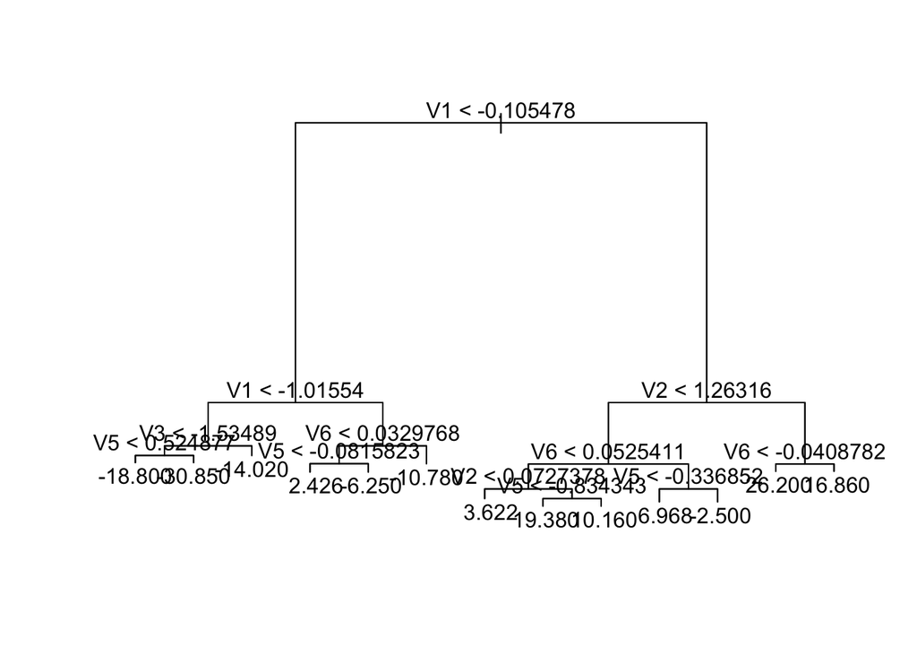

```r
set.seed(1)
t <- tree(y~., data = mvn.data)

plot(t)
text(t)
```

The deviance at each split is stored in the `tree` object. This can be used to formulate a variable importance. Summed over the whole tree, the variable importance, $\mathcal{V}(v)$, is defined as the total deviance from splits on that variable.

```r
rep(0,12) -> base.vi
names(mvn.data[,-13]) -> name
set.seed(1)
for(i in 1:12) {
  as.data.frame(t$frame)[,c(1,3)] %>% filter(var == name[i]) %>% dplyr::summarise(sum = sum(dev)) -> base.vi[i]
}
```

The variable importance before permuation for each variable is:

[output not shown]

Now let’s permute each variable with respect to it’s relationship with the other 11. Then the variable importance will be calculated again, many times, and a distribution will be made to account for the variablility in tree formation and in the partitions.

```r
intervalReturn <- function(split.cutleft){
  intervals <- data.frame(split.cutleft)
  intervals <- filter(intervals, split.cutleft != "")
  intervals <- dplyr::select(intervals, split.cutleft)
  intervals$split.cutleft <- gsub("<", "", intervals$split.cutleft)
  intervals$split.cutleft <- as.numeric(intervals$split.cutleft)
  return(arrange(intervals, (split.cutleft)))
}

partitionCreator <- function(i = interval, x, data) {
  p <- c(1:(1+nrow(i)))
  bins <- data.frame (bin = rep(1, nrow(data)), x = data[,x])
  for(j in 1:nrow(i)){
    bins[bins$x > i[j,1],1] <- p[j+ 1]
  }
  return(bins$bin)
}

condPermuter <- function(d2, x) {
  d2$p <- as.factor(d2$p)
  for(i in 1:length(levels(d2$p))){
   #set.seed(1)
   d2[d2$p == i, x] <- sample(d2[d2$p== i,x])
  }
  return(d2[,x])
}

VIdev<- function(t2, x){
  return(as.data.frame(t2$frame)[,c(1,3)] %>% filter(var == x) %>% dplyr::summarise(sum = sum(dev)))
}

variable.importance.dev <- function(t1, x, d){
  if(length(t1$frame$splits[,1]) == 1) {
    stop(paste(x, "is not correlated strongly with the other predictors, try another variable importance procedure"))
  } else {
  interval <- intervalReturn(t1$frame$splits[,1])
  d$p <- partitionCreator(interval, x, d)
  d[,x] <- condPermuter(d, x)
  t2 <- tree(y ~ ., data = d, y = TRUE)
  v1 <- VIdev(t2, x)
  #rm(t1, t2)
  return(v1)
  }
}
```

```r
v1vi <- rep(0,500)#init a vector for variable importance
v2vi <- rep(0,500)
v3vi <- rep(0,500)
v4vi <- rep(0,500)
v5vi <- rep(0,500)
v6vi <- rep(0,500)
v7vi <- rep(0,500)
v8vi <- rep(0,500)
v9vi <- rep(0,500)
v10vi <- rep(0,500)
v11vi <- rep(0,500)
v12vi <- rep(0,500)

p.vi <- rep(0,12)

d = mvn.data
set.seed(1)
t1 <- tree(V1 ~., data = mvn.data[,-13])
for (i in 1:500){
v1vi[i] <- variable.importance.dev(t1, "V1", d = mvn.data)
#d <- select(mvn.data, -p)
}

p.vi[1] <- median(as.data.frame(t(as.data.frame(v1vi)))$V1)

set.seed(1)
t2 <- tree(V2 ~., data = mvn.data[,-13])
for (i in 1:500){
v2vi[i] <- variable.importance.dev(t2, "V2", d = mvn.data)
#d <- select(mvn.data, -p)
}
p.vi[2] <- median(as.data.frame(t(as.data.frame(v2vi)))$V1)

set.seed(1)
t3 <- tree(V3 ~., data = mvn.data[,-13])
for (i in 1:500){
v3vi[i] <- variable.importance.dev(t3, "V3", d = mvn.data)
#d <- select(mvn.data, -p)
}
p.vi[3] <- median(as.data.frame(t(as.data.frame(v3vi)))$V1)

set.seed(1)
t4 <- tree(V4 ~., data = mvn.data[,-13])
for (i in 1:500){
v4vi[i] <- variable.importance.dev(t4, "V4", d = mvn.data)
#d <- select(mvn.data, -p)
}
p.vi[4] <- median(as.data.frame(t(as.data.frame(v4vi)))$V1)


# set.seed(1)
# t5 <- tree(V5 ~., data = mvn.data[,-13])
# for (i in 1:500){
# v5vi[i] <- variable.importance.dev(t5, "V5", d = mvn.data)
# #d <- select(mvn.data, -p)
# }
# p.vi[5] <- mean(as.data.frame(t(as.data.frame(v5vi)))$V1)
#
# set.seed(1)
# t6 <- tree(V6 ~., data = mvn.data[,-13])
# for (i in 1:500){
# v6vi[i] <- variable.importance.dev(t6, "V6", d = mvn.data)
# #d <- select(mvn.data, -p)
# }
# p.vi[6] <- mean(as.data.frame(t(as.data.frame(v6vi)))$V1)
#
# set.seed(1)
# t7 <- tree(V7 ~., data = mvn.data[,-13])
# for (i in 1:500){
# v7vi[i] <- variable.importance.dev(t7, "V7", d = mvn.data)
# #d <- select(mvn.data, -p)
# }
# p.vi[7] <- mean(as.data.frame(t(as.data.frame(v7vi)))$V1)
#
# set.seed(1)
# t8 <- tree(V8 ~., data = mvn.data[,-13])
# for (i in 1:500){
# v8vi[i] <- variable.importance.dev(t8, "V8", d = mvn.data)
# #d <- select(mvn.data, -p)
# }
# p.vi[8] <- mean(as.data.frame(t(as.data.frame(v8vi)))$V1)
#
# #set.seed(1)
# #for (i in 1:500){
# #v9vi[i] <- variable.importance.dev(V9~., "V9", d = mvn.data)
# #d <- select(mvn.data, -p)
# #}
# #p.vi[9] <- mean(as.data.frame(t(as.data.frame(v9vi)))$V1)
#
# #set.seed(1)
# #for (i in 1:500){
# #v10vi[i] <- variable.importance.dev(V10~., "V10", d = mvn.data)
# #d <- select(mvn.data, -p)
# #}
# #p.vi[10] <- mean(as.data.frame(t(as.data.frame(v10vi)))$V1)
#
# #set.seed(1)
# #for (i in 1:500){
# #v11vi[i] <- variable.importance.dev(V11~., "V11", d = mvn.data)
# #d <- select(mvn.data, -p)
# #}
# #p.vi[11] <- mean(as.data.frame(t(as.data.frame(v11vi)))$V1)
#
# #set.seed(1)
# #for (i in 1:500){
# #v12vi[i] <- variable.importance.dev(V12~., "V12", d = mvn.data)
# #d <- select(mvn.data, -p)
# #}
# #p.vi[12] <- mean(as.data.frame(t(as.data.frame(v12vi)))$V1)

p.vi
```

```
##  [1] 0 0 0 0 0 0 0 0 0 0 0 0
```

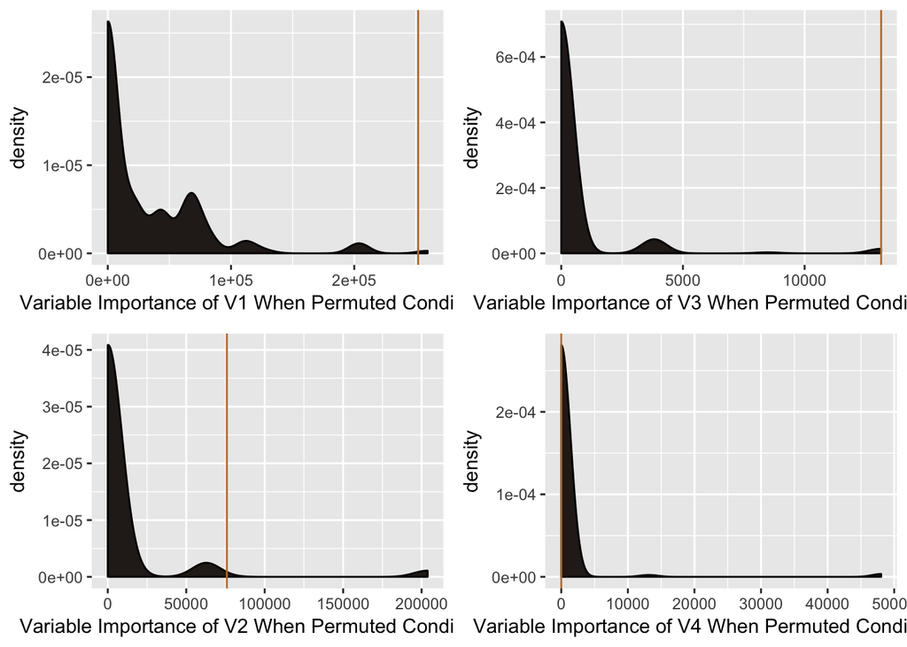

```r
p <- ggplot(data = as.data.frame(t(as.data.frame(v1vi))), aes(x = V1)) +
  geom_density(fill = "#29211F")+
  xlab("Variable Importance of V1 When Permuted Conditionally")+
  geom_vline(xintercept =  base.vi[[1]], color = "#C27D38")

q <- ggplot(data = as.data.frame(t(as.data.frame(v2vi))), aes(x = V1)) +
  geom_density(fill = "#29211F")+
  xlab("Variable Importance of V2 When Permuted Conditionally")+
  geom_vline(xintercept =  base.vi[[2]], color = "#C27D38")
r <- ggplot(data = as.data.frame(t(as.data.frame(v3vi))), aes(x = V1)) +
  geom_density(fill = "#29211F")+
  xlab("Variable Importance of V3 When Permuted Conditionally")+
  geom_vline(xintercept =  base.vi[[3]], color = "#C27D38")
s <- ggplot(data = as.data.frame(t(as.data.frame(v4vi))), aes(x = V1)) +
  geom_density(fill = "#29211F")+
  geom_vline(xintercept =  base.vi[[4]], color = "#C27D38")+
  xlab("Variable Importance of V4 When Permuted Conditionally")
#grid.arrange(p, q, r, s, ncol = 2, main = "Distribution of Variable Importance for the Block Correlated Variables")

plots <- list()  # new empty list
plots[[1]] <- p
plots[[2]] <- q
plots[[3]] <- r
plots[[4]] <- s

multiplot(plotlist = plots, cols = 2)
```

If we consider our new permuted variable importance to be the distance from the median value of the permuted distribution to the original variable importance, we can compare the two.

[output not shown]

As the median is always zero for each of these variables, the permuted VI defined in this way is always equal to the original.